# On the Origin of the Matthew Effect: Insights from a Quantitative Theoretical Model

https://osf.io/vs9hp/

Matthew T. McBee, Matthew C. Makel, & Natasha L. Godkin

4/15/2018

# Open materials!

This slideshow

http://rpubs.com/mmcbee/origin

Preprint of the paper

https://psyarxiv.com/8a5qs

OSF project page with paper, code, slides, and supporting materials

https://osf.io/vs9hp/

[figure not shown]

# The Matthew Effect

- As one Nobel interviewee stated, “The world… tends to give the credit to already famous people” (Merton, 1988, p. 607).
- “For whoever has will be given more, and they will have an abundance. Whoever does not have, even what they have will be taken from them.” Matthew 25:29. NIV
- Further widening the gap between those who had from those who had not

# Excellence and Achievement gaps

- Matthew Effects are particularly relevant for gifted education due to pervasive excellence gaps. Excellence gaps represent performance differences between sub-groups at the high end of achievement (Plucker and Peters, 2016)

[figure not shown]

# Ceci and Papierno (2005)

- Matthew Effects have been found in numerous domains
- Those who had an initial advantage or accomplishment, reaped not just rewards, but outsized rewards
- Relevant for policy decision
- Who gets the interventions?

# ZPD

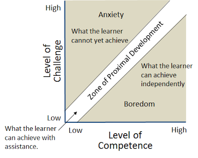

# Origin of the Matthew Effect

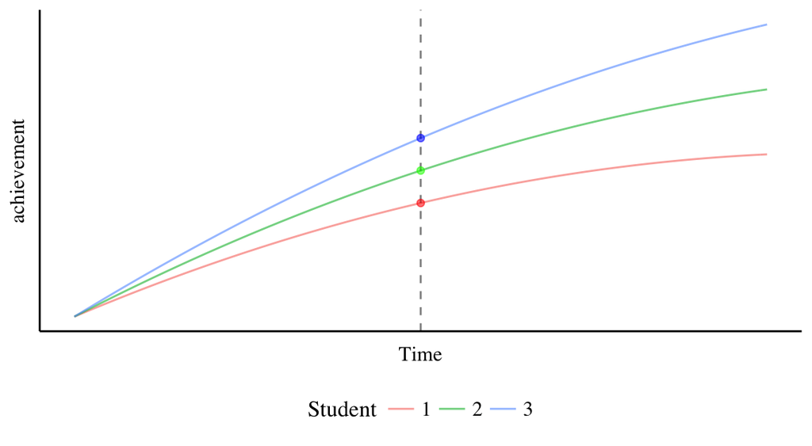

Origin of the Matthew effect. *X*-axis: time. *Y*-axis: achievement. Students are observed at a time point denoted by the vertical dashed line. The process creating the discrepancies in achievement at time *t* will continue unless interrupted or constrained, resulting in growing inequality in achievement over time.

# ZPDGrowthTrajectories model

- Uses a quantitative theoretical model to understand the consequences of various interventions on achievement and excellence gaps.
- Model generates synthetic acheivement growth trajectories.
- Implemented as an `R` package https://github.com/mcbeem/ZPDGrowthTrajectories
- Model is based on four underlying variables:
  - The child’s basic learning rate,
  - The educational quality of the child’s home environment
  - How quickly the child forgets things learned
  - Educational experiences to which the child is exposed in school

# Model equations

$$\begin{equation}
\begin{split}
\textit{Learning}_{ti} = & (\textit{LearnRate}_i) \, \times \, \\
& \big[ ( \textit{dosage}_{ti}) \int_{0}^{\infty} \textit{ZPD}_{ti}(x) * S_t(x) \, dx + \\
& (1-\textit{dosage}_{ti}) (\textit{HomeEnv}_i) \int_{0}^{\infty} \textit{ZPD}_{ti}(x) * H_t(x) \, dx \big]
\end{split}
\end{equation}$$

# Model equations

Achievement is updated for time interval $t$ by adding the amount of learning during that interval to the student’s prior achievement and then multiplying the result by a value slightly smaller than 1.0 to model decay due to forgetting.

$$\begin{equation}
\textit{Achievement}_{i,t}=(\textit{Achievement}_{i,t-1} + \textit{Learning}_{i,t})(1 - \textit{Decay}_i)
\end{equation}$$

# NWEA MAP national norms by subject and grade.

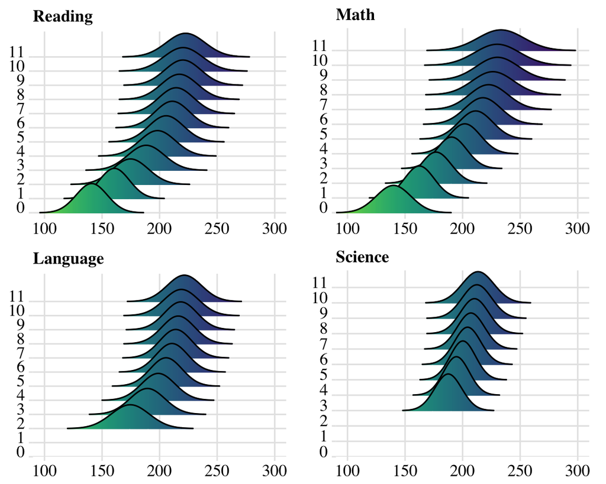

# Representation of current achievement and the ZPD

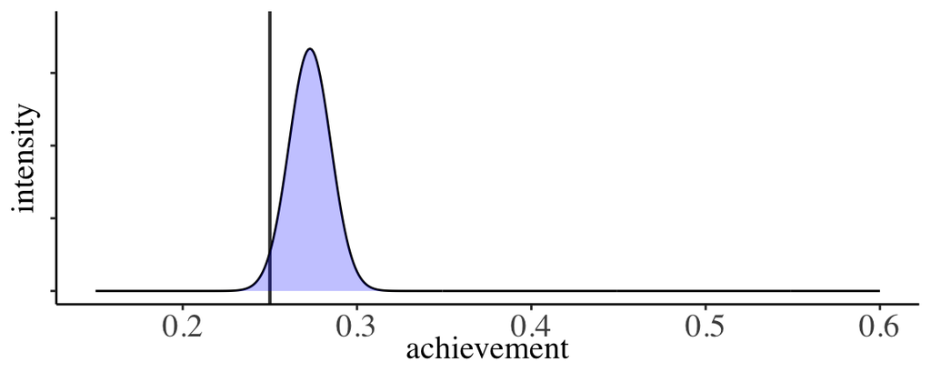

The student’s current level of achievement in a particular subject is represented by the vertical line. The student’s ZPD is the shaded curve. Instruction is effective at producing academic growth when it aligns with this range.

# Interaction of the ZPD with the school curriculum function

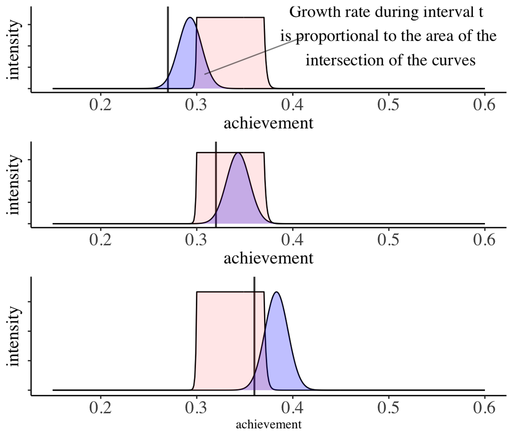

The growth rate during interval t is proportional to the intersection area of the ZPD curve (blue) with the school curriculum function (red).

# Interaction of the ZPD with the home curriculum function

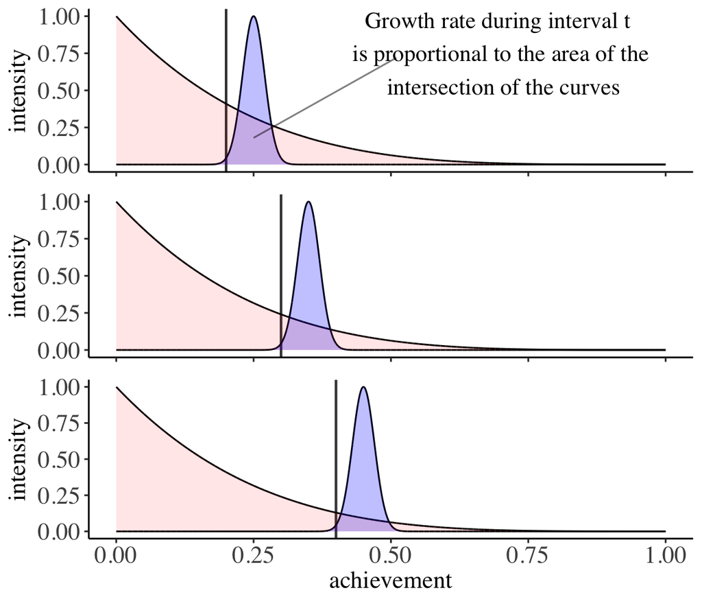

The growth rate during interval t is proportional to the intersection area of the ZPD curve (blue) with the home curriculum function (red).

# Real versus simulated piecewise model results

| Level | Component | Empirical | Simulated |
| --- | --- | --- | --- |
| Fixed effects | Intercept | 193.72 (.084) | 190.29 (.053) |
|  | High-achieving | 25.24 (.244) | 25.79 (.313) |
|  | School year | 1.54 (.024) | 1.58 (.009) |
|  | School year * High-ach | -1.28 (.025) | -1.32 (.052) |
|  | Summer | -0.12 (.033) | -.083 (.015) |
|  | Summer * High-ach | 0.24 (.036) | 0.504 (.090) |
|  | School year squared | -0.02 (.001) | -.021 (.003) |
|  | School year squared * High-ach | 0.03 (.001) | .032 (.002) |
|  | Summer squared | .001 (.002) | -0.004 (.001) |
|  | Summer squared * High-ach | -0.001 (.002) | -.025 (.007) |
| Random effects | Level-1 eij | 29.890 | 28.896 |
|  | Intercept | 30.601 | 30.761 |
|  | School year growth | 0.100 | 0.286 |
|  | Summer growth | - | - |
|  | School year growth squared | 0.000 | 0.000 |
|  | Summer growth squared | - | - |

# Individual-differences parameters for the three simulated students

| Student | Learning rate | Home environment | Decay rate |
| --- | --- | --- | --- |
| 1 | 0.145 | 0.09 | 0.010 |
| 2 | 0.175 | 0.21 | 0.008 |
| 3 | 0.190 | 0.34 | 0.001 |

# Model 1: Business-as-usual

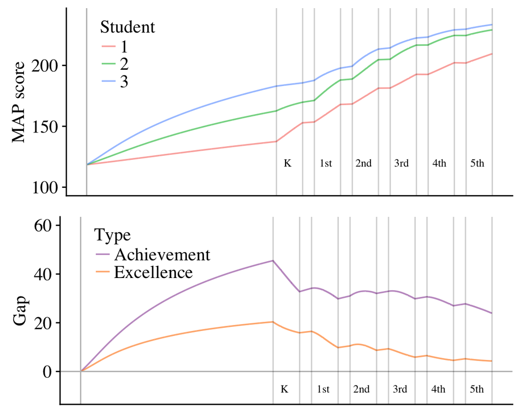

Synthetic trajectories and gaps for three students. *Condition*: no intervention; standard multilevel curriculum (e.g., typical, remedial, and advanced). *Panel 1*: Achievement trajectories for birth through grade five in reading. *Panel 2:* Gaps (achievement differential). The ‘achievement gap’ is difference between student three and student one; the ‘excellence gap’ is the difference between student three and student two.

# Model 2: Intervention to increase learning rates

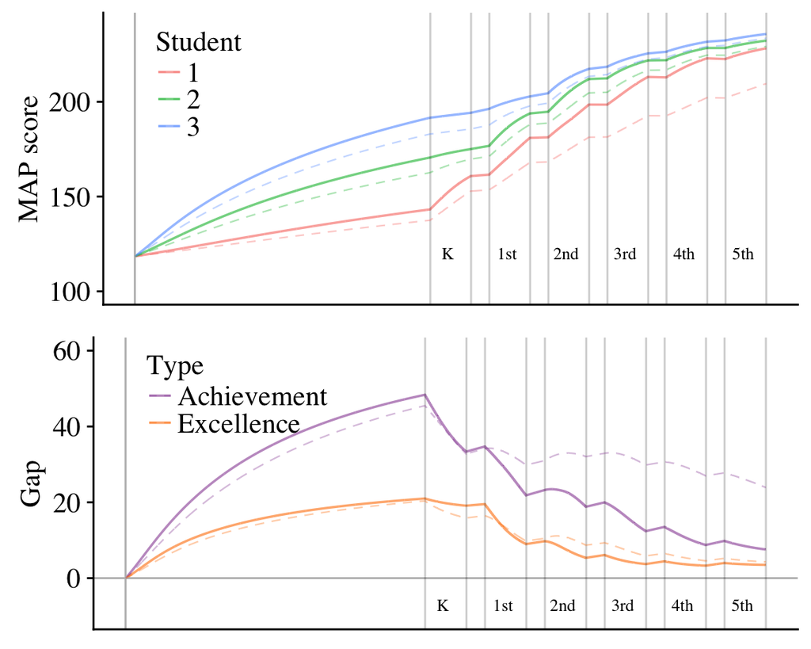

*Condition*: intervention with additive impact on learning rates; standard multilevel curriculum (e.g., typical, remedial, and advanced). *Panel 1*: Achievement trajectories. *Panel 2:* Gaps. Dotted reference lines display the no-intervention results for comparison.

# Model 3: Intervention to improve the home environment

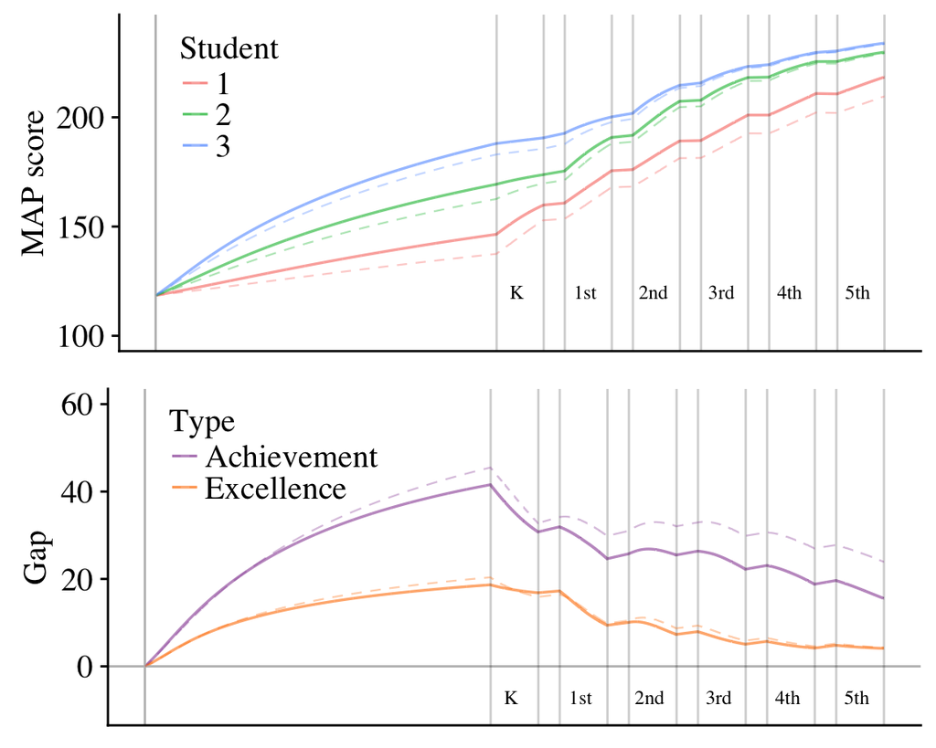

*Condition*: intervention with additive impact on home environment; standard multilevel curriculum (e.g., typical, remedial, and advanced). *Panel 1*: Achievement trajectories. *Panel 2:* Gaps. Dotted reference lines display the no-intervention results for comparison.

# Model 4: Increase dose (lengthen school day)

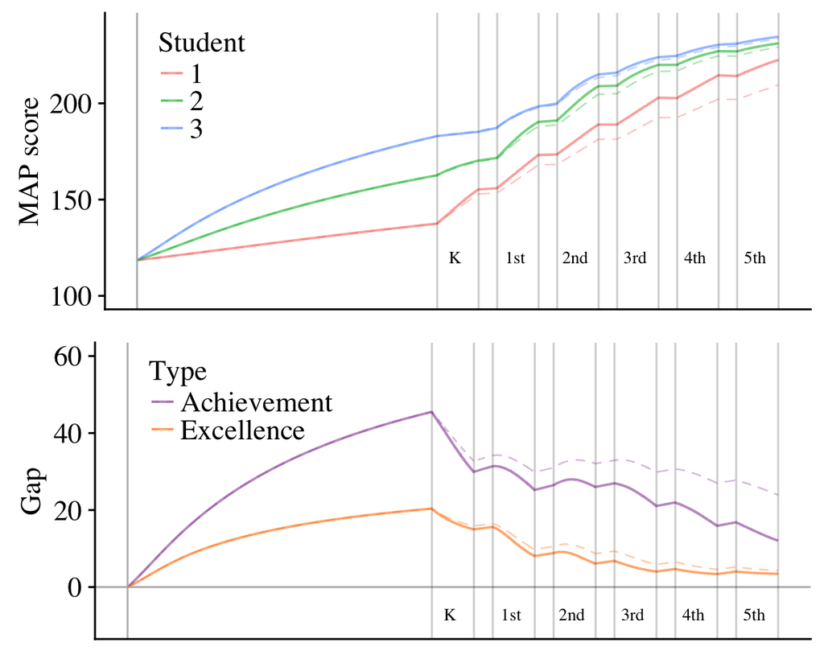

*Condition*: intervention to increase educational dose; standard multilevel curriculum (e.g., typical, remedial, and advanced). *Panel 1*: Achievement trajectories. *Panel 2:* Gaps. Dotted reference lines display the no-intervention results for comparison.

# Model 5: Completely individualized instruction

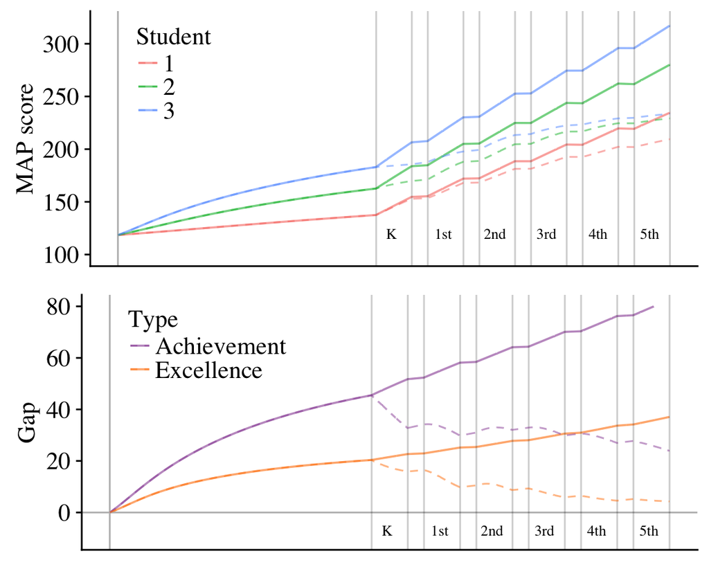

*Condition*: Individualized curriculum.

# Descriptive statistics of achievement by model and student

Achieved MAP score at the beginning of each grade by model and student.

| Model | Grade | 1 | 2 | 3 |
| --- | --- | --- | --- | --- |
| 1 | GradeK | 137.5 | 162.6 | 183.0 |
|  | Grade1 | 153.5 | 171.1 | 187.5 |
|  | Grade2 | 168.2 | 188.7 | 199.1 |
|  | Grade3 | 181.4 | 204.9 | 214.1 |
|  | Grade4 | 192.6 | 216.7 | 223.0 |
|  | Grade5 | 202.1 | 224.6 | 229.5 |
|  | Grade6 | 209.4 | 229.1 | 233.8 |
| 2 | GradeK | 143.2 | 170.6 | 191.6 |
|  | Grade1 | 161.5 | 176.6 | 196.1 |
|  | Grade2 | 181.2 | 194.6 | 204.2 |
|  | Grade3 | 198.5 | 212.3 | 218.2 |
|  | Grade4 | 212.9 | 221.9 | 226.1 |
|  | Grade5 | 222.7 | 228.4 | 232.1 |
|  | Grade6 | 228.0 | 232.2 | 236.1 |
| 3 | GradeK | 146.4 | 169.4 | 188.0 |
|  | Grade1 | 160.7 | 175.3 | 192.5 |
|  | Grade2 | 176.0 | 191.6 | 201.6 |
|  | Grade3 | 189.3 | 207.7 | 215.5 |
|  | Grade4 | 201.0 | 218.3 | 223.8 |
|  | Grade5 | 210.8 | 225.5 | 230.1 |
|  | Grade6 | 218.2 | 229.8 | 234.3 |
| 4 | GradeK | 137.5 | 162.6 | 183.0 |
|  | Grade1 | 155.8 | 171.6 | 187.1 |
|  | Grade2 | 173.4 | 191.0 | 199.7 |
|  | Grade3 | 189.0 | 209.1 | 215.7 |
|  | Grade4 | 202.8 | 220.0 | 224.5 |
|  | Grade5 | 214.3 | 227.0 | 230.8 |
|  | Grade6 | 222.3 | 231.1 | 234.9 |
| 5 | GradeK | 137.5 | 162.6 | 183.0 |
|  | Grade1 | 155.3 | 184.7 | 207.6 |
|  | Grade2 | 172.3 | 205.3 | 230.6 |
|  | Grade3 | 188.5 | 224.8 | 252.8 |
|  | Grade4 | 204.2 | 243.6 | 274.5 |
|  | Grade5 | 219.4 | 261.9 | 295.9 |
|  | Grade6 | 234.2 | 279.7 | 317.1 |

# Excellence gaps by grade and model

The excellence gap is defined as the achievement differential between the top two students. Excellence gaps at the beginning of each grade by model.

|  | Grade | Model1 | Model2 | Model3 | Model4 | Model5 |
| --- | --- | --- | --- | --- | --- | --- |
| 1 | GradeK | 20.4 | 21.0 | 18.7 | 20.4 | 20.4 |
| 3 | Grade1 | 16.4 | 19.5 | 17.2 | 15.6 | 22.9 |
| 5 | Grade2 | 10.4 | 9.6 | 10.0 | 8.7 | 25.4 |
| 7 | Grade3 | 9.2 | 5.9 | 7.8 | 6.6 | 28.0 |
| 9 | Grade4 | 6.3 | 4.2 | 5.5 | 4.5 | 30.8 |
| 11 | Grade5 | 5.0 | 3.7 | 4.6 | 3.8 | 34.0 |
| 13 | Grade6 | 4.6 | 3.9 | 4.4 | 3.8 | 37.4 |

# Achievement gaps by grade and model

Achievement gaps at the beginning of each grade by model.

| Grade | Model1 | Model2 | Model3 | Model4 | Model5 |
| --- | --- | --- | --- | --- | --- |
| GradeK | 45.5 | 48.4 | 41.6 | 45.5 | 45.5 |
| Grade1 | 34.1 | 34.6 | 31.8 | 31.3 | 52.3 |
| Grade2 | 30.8 | 23.0 | 25.6 | 26.3 | 58.4 |
| Grade3 | 32.7 | 19.7 | 26.2 | 26.7 | 64.3 |
| Grade4 | 30.4 | 13.2 | 22.8 | 21.7 | 70.3 |
| Grade5 | 27.5 | 9.4 | 19.3 | 16.5 | 76.4 |
| Grade6 | 24.3 | 8.1 | 16.0 | 12.5 | 82.9 |

# Why does this all matter?

- Huge implications for Educators, Policy makers and Quantitative Researchers
- Could help make more accurate predictions regarding changes in Excellent Gaps.

# Closing

[figure not shown]

- Those who had an initial advantage or accomplishment, reaped not just rewards, but outsized rewards

This slideshow

http://rpubs.com/mmcbee/origin

Preprint of the paper

https://psyarxiv.com/8a5qs

OSF project page with paper, code, slides, and supporting materials

https://osf.io/vs9hp/

[figure not shown]